# Model interpretation

Bodo Winter

7/10/2019

## Intro

Load packages:

```r
library(tidyverse)
library(gridExtra)
library(brms)
```

## Model selection stage

Check the outcome of 10-fold cross-validation comparisons between models:

```r
# Main model:

load('../models/kfold_main.RData')

# Models without interactions:

load('../models/kfold_no_mod_int.RData')
load('../models/kfold_no_triplet_int.RData')
load('../models/kfold_no_int.RData')

# Models without main effects:

load('../models/kfold_no_triplet.RData')
load('../models/kfold_no_mod.RData')
load('../models/kfold_no_cond.RData')
```

Check:

```r
kfold_main
```

```
##
## Based on 10-fold cross-validation
##
##            Estimate    SE
## elpd_kfold  -5360.3  50.4
## p_kfold          NA    NA
## kfoldic     10720.6 100.7
```

```r
kfold_no_mod_int
```

```
##
## Based on 10-fold cross-validation
##
##            Estimate    SE
## elpd_kfold  -5363.4  51.0
## p_kfold          NA    NA
## kfoldic     10726.9 101.9
```

```r
kfold_no_triplet_int
```

```
##
## Based on 10-fold cross-validation
##
##            Estimate    SE
## elpd_kfold  -5473.2  53.9
## p_kfold          NA    NA
## kfoldic     10946.3 107.8
```

Compare:

```r
compare_ic(kfold_main, kfold_no_mod_int)
```

```
##                            KFOLDIC     SE
## mdl_main                  10720.64 100.71
## mdl_no_mod_int            10726.89 101.92
## mdl_main - mdl_no_mod_int    -6.25  24.53
```

```r
compare_ic(kfold_main, kfold_no_triplet_int)
```

```
##                                KFOLDIC     SE
## mdl_main                      10720.64 100.71
## mdl_no_triplet_int            10946.35 107.77
## mdl_main - mdl_no_triplet_int  -225.71  53.13
```

The values indicate that there’s no reliable difference in predicting unseen data between the full model (with modality * condition interaction) and the model without this interaction. This suggests that the modality * condition interaction does not play a huge role.

Check k-fold comparisons for the other effects:

```r
compare_ic(kfold_no_int, kfold_no_mod)
```

```
##                          KFOLDIC     SE
## mdl_no_int              10893.88 104.70
## mdl_no_mod              10898.03 105.44
## mdl_no_int - mdl_no_mod    -4.14  26.98
```

```r
compare_ic(kfold_no_int, kfold_no_cond)
```

```
##                           KFOLDIC     SE
## mdl_no_int               10893.88 104.70
## mdl_no_cond              11005.23 113.07
## mdl_no_int - mdl_no_cond  -111.35  33.95
```

```r
compare_ic(kfold_no_int, kfold_no_triplet)
```

```
##                              KFOLDIC     SE
## mdl_no_int                  10893.88 104.70
## mdl_no_triplet              12502.92 138.68
## mdl_no_int - mdl_no_triplet -1609.04 101.89
```

There does not seem to be evidence for a reliable modality effect.

Load main model:

```r
load('../models/mdl_no_mod_int.RData')

# Rename for simplicity:

xmdl <- mdl_no_mod_int
```

## Check the R-squared of the model:

Check:

```r
bayes_R2(xmdl)
```

```
##     Estimate   Est.Error      Q2.5     Q97.5
## R2 0.8135925 0.004569241 0.8043207 0.8223348
```

## Print the chosen model:

Check the model:

```r
summary(xmdl)
```

```
##  Family: binomial
##   Links: mu = logit
## Formula: Correct | trials(15) ~ 1 + DigitSpan_c + Pos_c + Pos_c2 + mo(Triplet) + Modality + Condition + mo(Triplet):Condition + (1 + Pos_c + Pos_c2 + mo(Triplet) + Condition + mo(Triplet):Condition | ID)
##    Data: recall (Number of observations: 2808)
## Samples: 4 chains, each with iter = 4000; warmup = 2000; thin = 1;
##          total post-warmup samples = 8000
##
## Group-Level Effects:
## ~ID (Number of levels: 78)
##                                                                    Estimate
## sd(Intercept)                                                          0.65
## sd(Pos_c)                                                              0.16
## sd(Pos_c2)                                                             0.05
## sd(ConditionIntonationA)                                               0.79
## sd(ConditionIntonationB)                                               0.72
## sd(ConditionPause)                                                     0.87
## sd(moTriplet)                                                          0.19
## sd(moTriplet:ConditionIntonationA)                                     0.32
## sd(moTriplet:ConditionIntonationB)                                     0.25
## sd(moTriplet:ConditionPause)                                           0.21
## cor(Intercept,Pos_c)                                                   0.02
## cor(Intercept,Pos_c2)                                                 -0.31
## cor(Pos_c,Pos_c2)                                                      0.33
## cor(Intercept,ConditionIntonationA)                                   -0.26
## cor(Pos_c,ConditionIntonationA)                                       -0.10
## cor(Pos_c2,ConditionIntonationA)                                       0.02
## cor(Intercept,ConditionIntonationB)                                   -0.38
## cor(Pos_c,ConditionIntonationB)                                       -0.07
## cor(Pos_c2,ConditionIntonationB)                                      -0.03
## cor(ConditionIntonationA,ConditionIntonationB)                         0.67
## cor(Intercept,ConditionPause)                                         -0.20
## cor(Pos_c,ConditionPause)                                              0.10
## cor(Pos_c2,ConditionPause)                                             0.06
## cor(ConditionIntonationA,ConditionPause)                               0.51
## cor(ConditionIntonationB,ConditionPause)                               0.32
## cor(Intercept,moTriplet)                                               0.43
## cor(Pos_c,moTriplet)                                                   0.08
## cor(Pos_c2,moTriplet)                                                 -0.22
## cor(ConditionIntonationA,moTriplet)                                   -0.22
## cor(ConditionIntonationB,moTriplet)                                   -0.38
```

[output cut: 344 more lines]

```
## moTriplet:ConditionPause1[1]           0.09      0.06     0.00     0.22
## moTriplet:ConditionPause1[2]           0.91      0.06     0.78     1.00
##                                    Eff.Sample Rhat
## moTriplet1[1]                            2623 1.00
## moTriplet1[2]                            2623 1.00
## moTriplet:ConditionIntonationA1[1]       5577 1.00
## moTriplet:ConditionIntonationA1[2]       5577 1.00
## moTriplet:ConditionIntonationB1[1]       4556 1.00
## moTriplet:ConditionIntonationB1[2]       4556 1.00
## moTriplet:ConditionPause1[1]             4697 1.00
## moTriplet:ConditionPause1[2]             4697 1.00
##
## Samples were drawn using sampling(NUTS). For each parameter, Eff.Sample
## is a crude measure of effective sample size, and Rhat is the potential
## scale reduction factor on split chains (at convergence, Rhat = 1).
```

First, it needs to be pointed out that the model seems to have converged properly (all Rhat values exactly 1.00).

Notice a few things:

- the intercept is the control condition for the oral response modality
- the CI for the triplet_fac3 coefficient is above 0, indicating that even for the control condition, the third position is more accurate; this seems to suggest that people chunk anyway
- compared to control, intonation A and intonation B both lead to an increase in accuracy (remember that the reference level is “oral” here, so this is the simple effect for “oral” only)
- the “pause” condition also leads to an increase against “control”, but not by as much
- there are interactions between both penultimate and ultimate triplet conditions and Intonation A and B, in the predicted direction (intonation = better)
- for the third position within a triplet, there also is a positive pause coefficient, which suggests that people have recency effects within a triplet

However, these are just the coefficients of the model. To better interpret the model, it’s best to look at the marginal effects.

## Marginal effects:

Extract marginal effects:

```r
condition <- marginal_effects(xmdl, "Condition")
modality <- marginal_effects(xmdl, "Modality")
triplet <- marginal_effects(xmdl, "Triplet")
condition_modality <- marginal_effects(xmdl,
                                       "Condition:Modality")
condition_triplet <- marginal_effects(xmdl,
                                      "Condition:Triplet")
```

Plot the overall condition effect (ignoring all other variables).

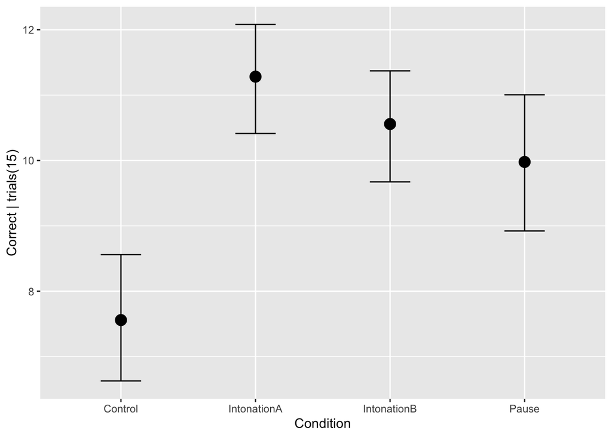

```r
condition
```

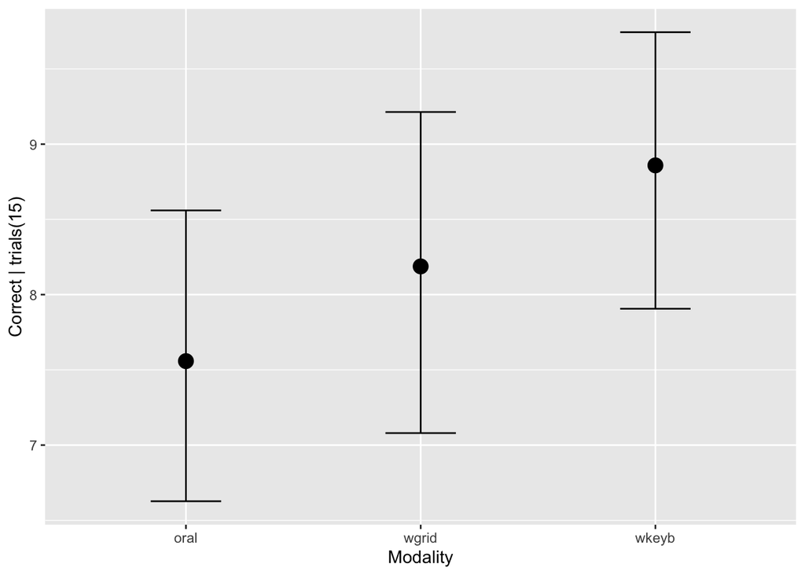

```r
modality
```

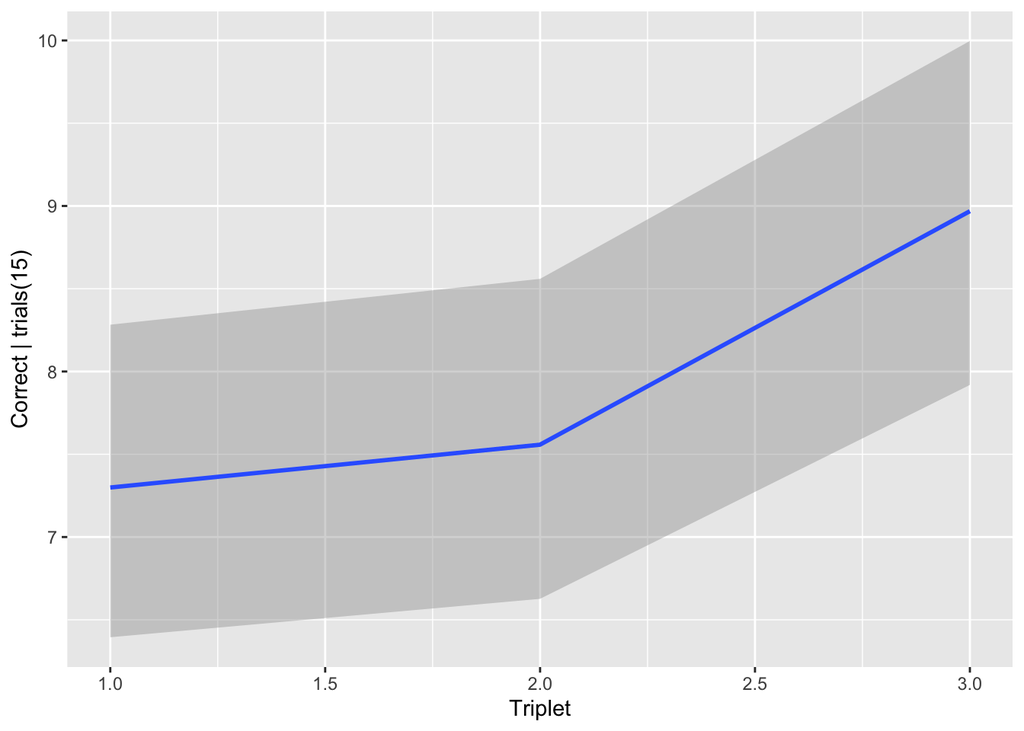

```r
triplet
```

A tendency for people to be better with the third within a triplet. This can be interpreted as a recency effect within a triplet. To some extent this may be because there’s three conditions in this experiment that have a triplet-based structure, so taking the marginal over the entire experiment, the third position is going to be particularly easy in the average.

Triplet by condition:

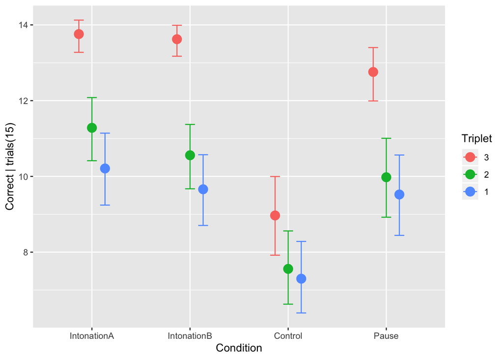

```r
condition_triplet
```

The third position is really good for intonation A and B, as well as for pause (a bit worse here). The third position is not at all that good within the control condition. However, the fact that it is slightly higher may suggest that people spontaneously chunk in threes, OR it is due to the averaging with the grid condition also being in there (more likely the latter).

## Posterior probabilities of the relevant effects

In this section, we will extract the relevant posterior samples and calculate the posterior probability for the effects we are interested in, e.g., the predicted probability of “oral” being worse than “grid” and “key”. Or the posterior probability of intonation “A” being better than “control” etc.

In doing this, we need to pay special attention about the interactions, but we can ignore the non-interacting variables (such as digit span).

First, extract the posterior samples into a data frame:

```r
posts <- posterior_samples(xmdl)
```

Just to check, these are the first two rows of that part of the data frame with the posteriors that deals with the posteriors for the fixed effect:

```r
select(posts,
       b_Intercept:`bsp_moTriplet:ConditionPause`) %>% slice(1:2)
```

```
##   b_Intercept b_DigitSpan_c    b_Pos_c   b_Pos_c2 b_Modalitywgrid
## 1  -0.6450289     0.5279008 -0.3014444 0.08274897       0.1962565
## 2  -0.7210651     0.5875031 -0.3183309 0.07398098       0.1660900
##   b_Modalitywkeyb b_ConditionIntonationA b_ConditionIntonationB
## 1       0.4269184              0.8322358              0.6055734
## 2       0.6951034              0.8400668              0.6678339
##   b_ConditionPause bsp_moTriplet bsp_moTriplet:ConditionIntonationA
## 1        0.5519661     0.1352721                          0.6502001
## 2        0.6070194     0.2331434                          0.6011001
##   bsp_moTriplet:ConditionIntonationB bsp_moTriplet:ConditionPause
## 1                          0.6967677                    0.3788236
## 2                          0.6571495                    0.3803295
```

Let’s extract the relevat columns into nice objects, so that we can perform simple arithmetic:

```r
intercept <- pull(posts, b_Intercept)
triplet <- pull(posts, bsp_moTriplet)
mod_grid <- pull(posts, b_Modalitywgrid)
mod_key <- pull(posts, b_Modalitywkeyb)
intoA <- pull(posts, b_ConditionIntonationA)
intoB <- pull(posts, b_ConditionIntonationB)
pause <- pull(posts, b_ConditionPause)
triplet_intoA <- pull(posts, `bsp_moTriplet:ConditionIntonationA`)
triplet_intoB <- pull(posts, `bsp_moTriplet:ConditionIntonationB`)
triplet_pause <- pull(posts, `bsp_moTriplet:ConditionPause`)
```

What is the probability of the coefficients being larger than the others?

```r
## Interactions:

sum(triplet_intoA > triplet_intoB) / nrow(posts)
```

```
## [1] 0.332375
```

```r
sum(triplet_intoA > triplet_pause) / nrow(posts)
```

```
## [1] 0.99975
```

```r
sum(triplet_intoB > triplet_pause) / nrow(posts)
```

```
## [1] 0.999875
```

```r
# Grid effect:

sum(mod_grid > 0) / nrow(posts)
```

```
## [1] 0.788875
```

```r
sum(mod_key > 0) / nrow(posts)
```

```
## [1] 0.976375
```

This completes this analysis.